# Estimating risk measures for normal variance mixture distributions

Erik Hintz, Marius Hofert and Christiane Lemieux

2025-09-10

```r
library(nvmix)
library(RColorBrewer)
doPDF <- FALSE
```

## Introduction

A random vector $\mathbf{X}=(X_1,\dots,X_d)$ follows a *normal variance mixture*, in notation $\mathbf{X}\sim \operatorname{NVM}_d(\mathbf{\mu},\Sigma,F_W)$, if, in distribution,
$$\mathbf{X} = \mathbf{\mu}+\sqrt{W}A\mathbf{Z},$$
where $\mathbf{\mu}\in\mathbb{R}^d$ denotes the *location (vector)*, $\Sigma=AA^\top$ for $A\in\mathbb{R}^{d\times k}$ denotes the *scale (matrix)* (a covariance matrix), and the mixture variable $W\sim F_W$ is a non-negative random variable independent of $\mathbf{Z}\sim\operatorname{N}_k(\mathbf{0},I_k)$ (where $I_k\in\mathbb{R}^{k\times k}$ denotes the identity matrix). Both the Student’s $t$ distribution with degrees of freedom parameter $\nu>0$ and the normal distribution are normal variance mixtures; in the former case, $W\sim\operatorname{IG}(\nu/2, \nu/2)$ (inverse gamma) and in the latter case $W$ is almost surely constant (taken as $1$ so that $\Sigma$ is the covariance matrix of $\mathbf{X}$ in this case).

It follows readily from the stochastic representation that linear combinations of multivariate normal variance mixtures are univariate normal variance mixtures. Let $\mathbf{a}\in\mathbb{R}^d$. If $\mathbf{X}\sim \operatorname{NVM}_d(\mathbf{\mu}, \Sigma,F_W)$, then $\mathbf{a}^\top \mathbf{X} \sim \operatorname{NVM}_1(\mathbf{a}^\top\mathbf{\mu}, \mathbf{a}^\top\Sigma\mathbf{a},F_W)$.

If $\mathbf{X}$ models, for instance, financial losses, $\mathbf{a}^\top \mathbf{X}$ is the loss of a portfolio with portfolio weights $\mathbf{a}$. It is then a common task in risk management to estimate risk measures of the loss $\mathbf{a}^\top \mathbf{X}$. We consider the two prominent risk measures value-at-risk and expected shortfall.

## Estimating Risk Measures for $X\sim NVM_1(\mu, \sigma, F_W)$

In the following, assume without loss of generality that $X\sim \operatorname{NVM}_1(0, 1, F_W)$, the general case follows from a location-scale argument.

### Value-at-risk

The *value-at-risk* of $X$ at confidence level $\alpha\in(0,1)$ is merely the $\alpha$-quantile of $X$. That is,
$$\operatorname{VaR}_\alpha(X) =
\inf\{x\in[0,\infty):F_X(x)\ge \alpha\},$$
where $F_X(x)=\mathbb{P}(X\le x)$ for $x\in\mathbb{R}$ is the distribution function of $X$. Such quantile can be estimated via the function `qnvmix()`, or equivalently, via the function `VaR_nvmix()` of the `R` package `nvmix`.

As an example, consider $W\sim\operatorname{IG}(\nu/2, \nu/2)$ so that $X$ follows a $t$ distribution with $\nu$ degrees of freedom. In this case, the quantile is known. If the argument `qmix` is provided as a string, `VaR_nvmix()` calls `qt()`; if `qmix` is provided as a function or list, the quantile is internally estimated via a Newton algorithm where the univariate distribution function $F_X()$ is estimated via randomized quasi-Monte Carlo methods.

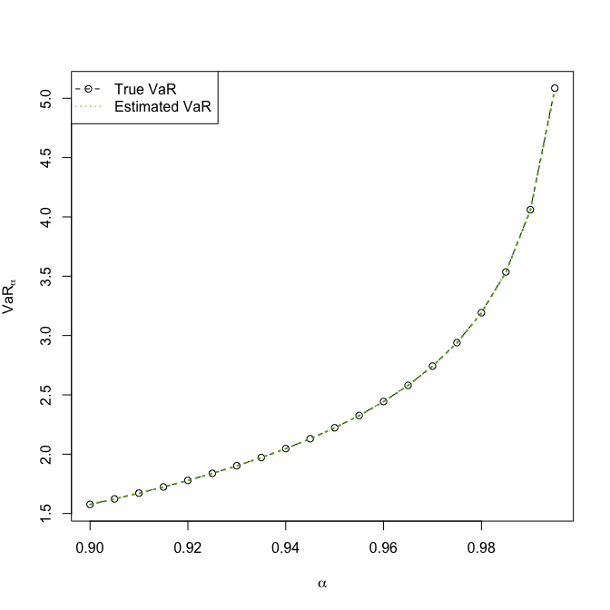

```r
set.seed(1) # for reproducibility
qmix  <- function(u, df) 1/qgamma(1-u, shape = df/2, rate = df/2)
df    <- 3.5
n     <- 20
level <- seq(from = 0.9, to = 0.995, length.out = n)
VaR_true <- VaR_nvmix(level, qmix = "inverse.gamma", df = df)
VaR_est  <- VaR_nvmix(level, qmix = qmix, df = df)
stopifnot(all.equal(VaR_true, qt(level, df = df)))
## Prepare plot
pal <- colorRampPalette(c("#000000", brewer.pal(8, name = "Dark2")[c(7, 3, 5)]))
cols <- pal(2) # colors
if(doPDF) pdf(file = (file <- "fig_VaR_nvmix_comparison.pdf"),
              width = 7, height = 7)
plot(NA, xlim = range(level), ylim = range(VaR_true, VaR_est),
     xlab = expression(alpha), ylab = expression(VaR[alpha]))
lines(level, VaR_true, col = cols[1], lty = 2, type = 'b')
lines(level, VaR_est,  col = cols[2], lty = 3, lwd = 2)
legend('topleft', c("True VaR", "Estimated VaR"), col = cols, lty = c(2,3),
       pch = c(1, NA))
if(doPDF) dev.off()
```

### Expected Shortfall

Another risk measure of great theoretical and practical importance is the *expected-shortfall*. The expected shortfall of $X$ at confidence level $\alpha\in(0,1)$ is, provided the integral converges, given by
$$\operatorname{ES}_\alpha(X) = \frac{1}{1-\alpha} \int_\alpha^1
\operatorname{VaR}_u(X)du.$$
If $F_X()$ is continuous, one can show that
$$\operatorname{ES}_\alpha(X) =
\operatorname{E}(X \mid X >
\operatorname{VaR}_\alpha(X)).$$

The function `ES_nvmix()` in the `R` package `nvmix` can be used to estimate the expected shortfall for univariate normal variance mixtures. Since these distributions are continuous, we get the following:

$$(1-\alpha) \operatorname{ES}_\alpha(X) = \operatorname{E}\left(X
\mathbf{1}_{\{X>\operatorname{VaR}_\alpha(X)\}}\right)=
\operatorname{E}\left( \sqrt{W} Z \mathbf{1}_{\{\sqrt{W} Z >
\operatorname{VaR}_\alpha\}}\right)$$

$$=
\operatorname{E}\Big( \sqrt{W} \operatorname{E}\big(Z
\mathbf{1}_{\{Z> \operatorname{VaR}_\alpha(X)/\sqrt{W}\}} \mid
W\big)\Big)=
\operatorname{E}\left(\sqrt{W} \phi(\operatorname{VaR}_\alpha(X) /
\sqrt{W})\right)$$

Here, $\phi(x)$ denotes the density of a standard normal distribution and we used that $\int_k^\infty x\phi(x)dx = \phi(k)$ for any $k\in\mathbb{R}$. Internally, the function `ES_nvmix()` estimates $\operatorname{ES}_\alpha(X)$ via a randomized quasi-Monte Carlo method by exploiting the displayed identity.

In case of the normal and $t$ distribution, a closed formula for the expected shortfall is known; this formula is then used by `ES_nvmix()` if `qmix` is provided as string.

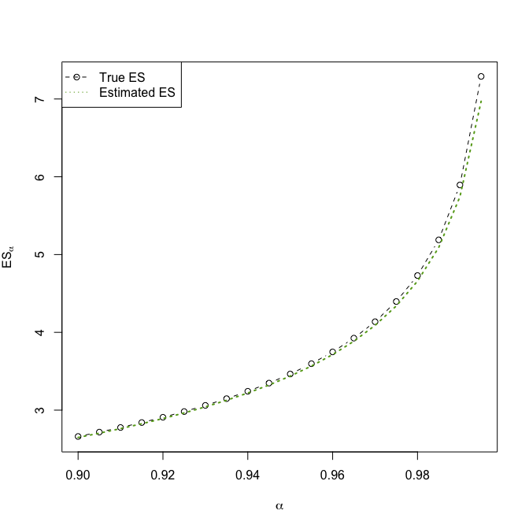

```r
ES_true <- ES_nvmix(level, qmix = "inverse.gamma", df = df)
ES_est  <- ES_nvmix(level, qmix = qmix, df = df)
## Prepare plot
if(doPDF) pdf(file = (file <- "fig_ES_nvmix_comparison.pdf"),
              width = 7, height = 7)
plot(NA, xlim = range(level), ylim = range(ES_true, ES_est),
     xlab = expression(alpha), ylab = expression(ES[alpha]))
lines(level, ES_true, col = cols[1], lty = 2, type = 'b')
lines(level, ES_est,  col = cols[2], lty = 3, lwd = 2)
legend('topleft', c("True ES", "Estimated ES"), col = cols, lty = c(2,3),
       pch = c(1, NA))
if(doPDF) dev.off()
```